# **HappyDB :)**

# **What makes your happy moments different from others?**

> By Xinyi Hu

[figure not shown]

HappyDB is a large scale collection of happy moments on Amazon Mechanical Turk (MTurk) workers. And HappyDB also collected the demographic information of these workers.

Happiness is the emotion that we all share. However, things that make us happy might be relatively different from each other. Therefore, this project aims to analyze whether gender, marital status, parenthood and cultural background would differ the things and events that make people feel happy.

# Section 1: Overview of the Happy Moments

This section focuses on analyzing all happy moments regardless of workers’ demographic information.

## Part 1: Wordcloud

Words that frequently appeared in MTurk workers’ happy moments descriptions are: **friend**, **day**, **time**, **watched**, **family** and **home** etc. Thus, generally people will feel happy about things or events related to their friends, families, watching shows and so on.

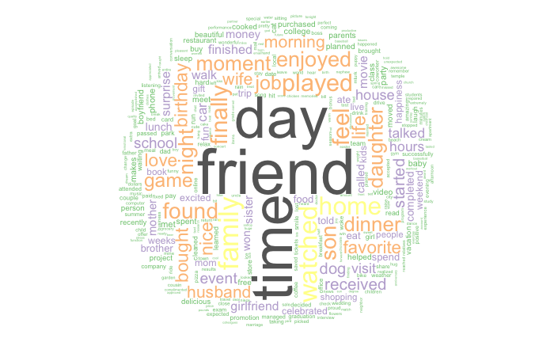

## Part 2: Relationships between word

In this part, I am interested in the relationships between words in all the happy moments descriptions. I want to whether examine which words tend to follow others immediately, or that tend to co-occur within the same documents.

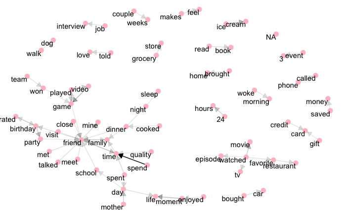

So I visualized some details of the text structure. We can see that words like **visit**, **party** and **school** are often followed by the word **friend**, which means when these events are related to friends, people usually get happy.

We also see some pairs or triplets along the outside that form common short phrases related to happy moments, such as **brought home** and **read book**.

## Part 3: Topic Modeling

Now in this part, I applied topic modeling to all the happy moments corpuses. I set the number of topics to be 9, which is the same as the number of ‘topic_dict’ in HappyDB data folder.

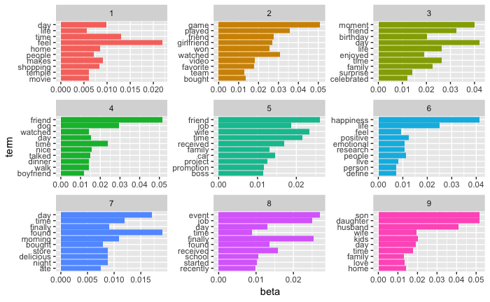

# Section 2: Analyze Happy Moments in Different Clusters

## Part 1: Gender

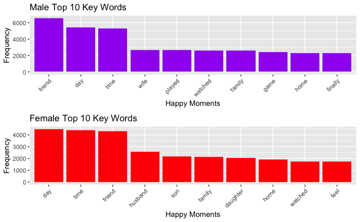

In both plots, the first 3 words are ‘friend’, ‘day’ and ‘time’. Their frequencies are almost equivalent in female data set, while in male data set, the word frequency of ‘friend’ is obviously higher than the other two words. And the fourth words in both data set are spouse, which is good.

In the male data set, words ‘played’, ‘watched’ rank higher than family. But in female data set, words related to family and home are in the front. So you can see the differences of happy moments between female and male.

## Part 4: Continent

In this final part, I sort Amazon MTurk workers into six main continents: Asia, Africa, Europe, Northern America, Southern America and Oceania. I want to know wether people’s cultural background will cause differences in terms of happiness.

| word | freq |
| --- | --- |
| friend | 1.65 |
| time | 1.48 |
| day | 1.40 |
| watched | 0.82 |
| finally | 0.74 |
| found | 0.73 |
| played | 0.73 |
| dinner | 0.68 |
| home | 0.67 |
| daughter | 0.65 |

Compared with other continents, workers from Africa talked about their friends a lot in their happy moments descriptions. And the word job appears only in Africa cluster.

In the Asia cluster, we only see one word which is kind of related to entertainment, that is enjoyed. It seems like And many Asian workers described their happy moments related to the word birthday which only appears in Asia cluster.

The first 10 popular words of workers from Northern America are somewhat similar to that of Europe. They all contain a couple of words related to entertainments like won played watched, and these words rank relatively high. But in terms of people and family, Europe cluster contains word girlfriend and then the word family, while Northern America cluster contains words home and daughter. Besides, word dinner shows up in Northern America cluster, it might suggest that dinner is something important in Northern American culture.

Let’s move on to the Southern America cluster. Workers from Southern America talked a lot about shopping and entertainments in their happy moments, because this cluster contains words buy played and game, and notice that the word buy ranks high.

Finally, let’s check Oceania cluster. The top 10 popular words of happy moments in this cluster is very different from the rest of 5 clusters. Word friend day and time do not rank very high. And we can see words like read and dog appear in this cluster.

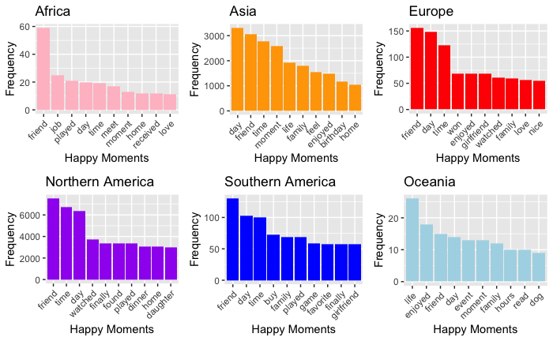

However, as you can see in the y-lab, it reveals that the number of workers from Africa, Southern America and Oceania is quite small, Oceania in particular. So the analysis on popular words in these two clusters is not very accurate.